# Matplotlib Part 2. Basic Example using Matplotlib

## Part 2. Basic Example using Matplotlib

### Table of Contents

1. Simple Example
2. Simple Commands
3. Multiple Plots on the Same Canvas

Let's start by importing the **pyploy** API from the **matplotlib** library. And **numpy** to create the data required to plot the graphs.

```python
import numpy as np

import matplotlib.pyplot as plt
%matplotlib inline
```

The above line of code **%matplotlib inline** is used in the ipython notebooks to plot graphs. In case of other editors we use **plt.plot()**.

### 1. Simple Eample

We will create two arrays using the `numpy.linspace` namely `x` and `y`. Then we will plot them in their respective axis using `pyplot.plot`.

```python
x = np.linspace(0, 10, 11)
y = x ** 2

print("x: ", x)
print("y: ", y)
```

```
x:  [ 0.  1.  2.  3.  4.  5.  6.  7.  8.  9. 10.]
y:  [  0.   1.   4.   9.  16.  25.  36.  49.  64.  81. 100.]
```

### 2. Simple Commands

1. We will plot a graph using `x` and `y`.
1. We will add labels to the `X` and `Y` Axes of the graph.
1. We will give a title to the graph.

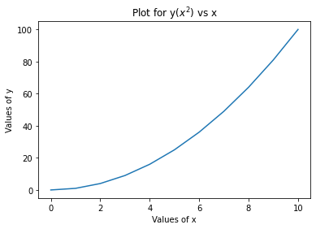

```python
plt.plot(x, y)
plt.xlabel('Values of x')
plt.ylabel('Values of y')
plt.title(r'Plot for y$(x^2)$ vs x')
plt.show()
```

### 3. Multiple Plots on the Same Canvas

1. We will start by using the `plt.subplot(nrows, ncols, plot_number)`. Here `nrows` sets the number of `Rows`, `ncols` sets the number of `Columns`. And `plot_number` sets which plot to use. This function will create (`nrows x ncols`) of plots. For example in the below case it creates `1 x 2 = 2 plots`.
1. Then we will select each plot at once and plot a graph in that particular plot, then we will move on to the next plot and plot a new graph again.

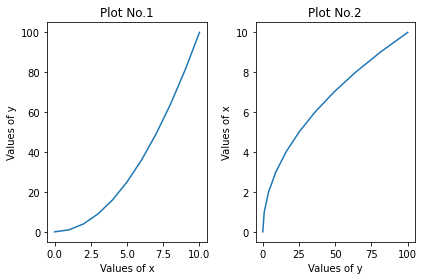

```python
# Working on plot 1
plt.subplot(1,2,1)
plt.plot(x, y)
plt.xlabel('Values of x')
plt.ylabel('Values of y')
plt.title('Plot No.1')


# Working on plot 2
plt.subplot(1,2,2)
plt.plot(y, x);
plt.xlabel('Values of y')
plt.ylabel('Values of x')
plt.title('Plot No.2')

# Use this function when your graphs
# gets plotted on top of one another.
plt.tight_layout()

plt.show()
```